# BSAN2204

Lecture 4

Data Processing

## Importing data into `R`

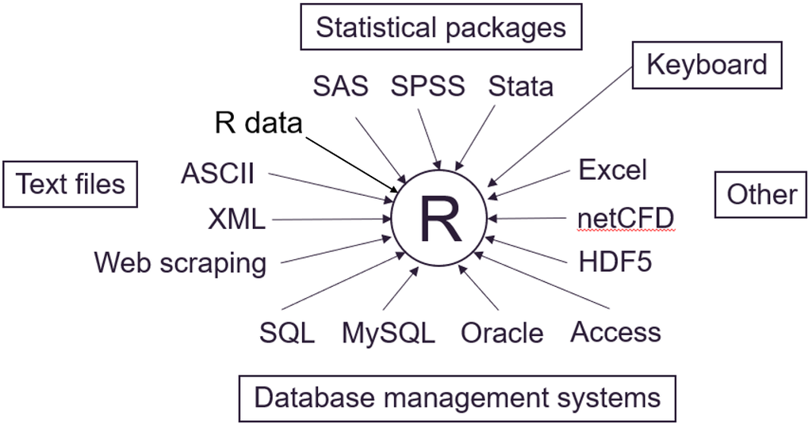

## Steps in a research project

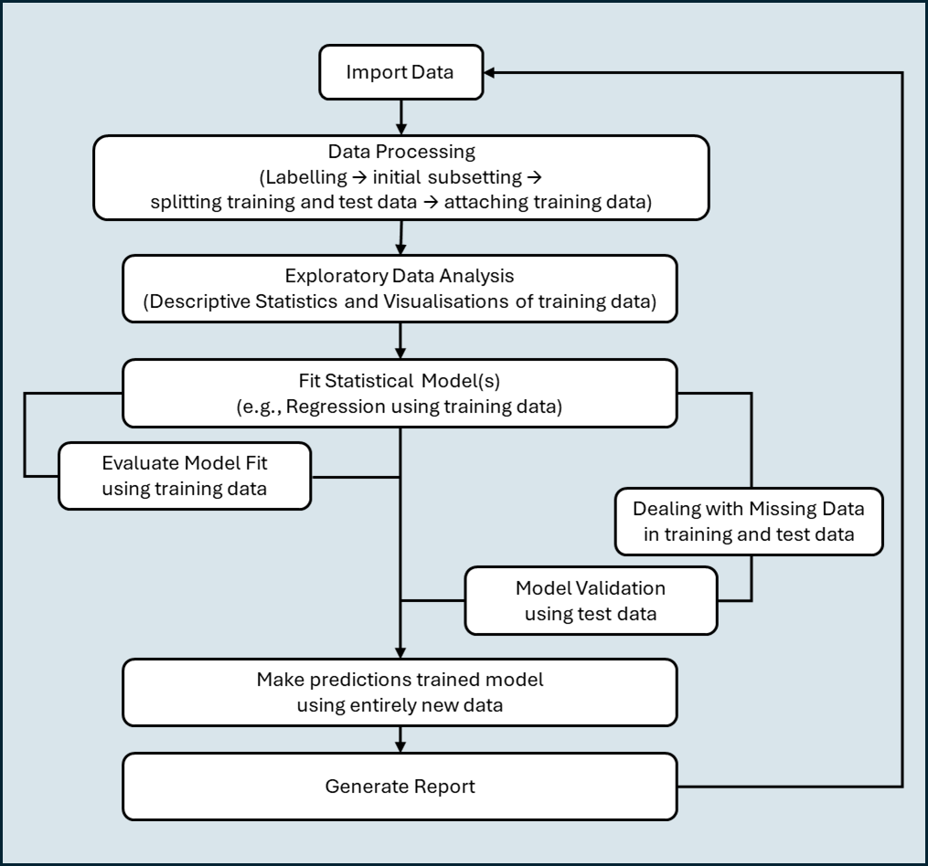

## Today’s lesson

We will cover the steps involved at the **Import Data** and **Data Processing** stage of the steps in a research project outlined on the previous slide.

In short, this will first comprise importing a dataset from some source (in our case a `.Rdata` file). Second, we will then cover the steps involved in in labelling data, choosing a subset of the data, and splitting the data into training and test data.

The latter of these steps (splitting the data into training and test data) lays the ground work for the model validation steps which come later in the project which we will come back to in a few weeks.

## Importing the `MSD` data frame

The `MSD` data is stored in a `.Rdata` file, a file type used by `R` to save objects from the global environment of an R session.

In this case the R object is a **data frame** that has the name `MSD`. Recall that data frames store rows and columns of data. Each row represents an *observation* whilst each column represents a *variable*.

Each of the columns of the data frame store can store different types of data (e.g., character, numeric, integer, factor).

## Using `load()`

The `load()` function is used in `R` to read R objects from a saved `.Rdata` file into the current workspace.

```r
load("MSD.Rdata")
```

## Inspecting data from the console

Before we start processing the data we should ensure we properly understand what is in the data. We will not write anything in the script editor panel at this stage. Instead, we will just work from the console and issue simple commands that return basic outputs that just for our own interpretation (i.e., we will not start writing our R Markdown document yet).

We will start simple and begin by looking at some of the data, listing the objects within the `MSD` data frame using simple console commands. The `MSD` data frame is essentially a table where each column can contain different types of data (e.g., numeric, character, logical). Using this information, we can explore different parts of the data frame.

## Looking at some data (in the console)

Use the `head()` or `tail()` functions to quickly check the first (or last) few rows of a data frame, vector or other object.

The purpose of this function is so you can quickly preview its contents as console output (it’s not pretty).

```r
head(MSD)
```

```
       artist_name artist_7digitalid artist_familiarity artist_hotttnesss
1 Faster Pussy cat              4069          0.6498221         0.3940319
2 Karkkiautomaatti            113480          0.4396040         0.3569921
3   Hudson Mohawke             63531          0.6436806         0.4375038
4      Yerba Brava             65051          0.4485012         0.3723491
5       Der Mystic            158279                 NA                NA
6 David Montgomery            219281          0.3612870         0.1096258
  duration end_of_fade_in key loudness mode
1 252.0551          2.049  10   -4.829    0
2 156.5514          0.258   9  -10.555    1
3 138.9710             NA   7   -2.060    1
4 145.0575             NA   7   -4.654    1
5 514.2983             NA   5   -7.806    0
6 816.5351          2.194  10  -21.420    1
                               release release_7digitalid song_hotttnesss
```

[output cut: 27 more lines]

Remember: any code that generates raw console output should not be included in a final report document!

## Looking at all the data (in the source pane)

Take a more complete “look” at the data by viewing it as a spreadsheet. This can be done using `View(MSD)` (typed into the console window) or by simply clicking the icon to the right of the object within the Environment pane in R studio.

Viewing the dataset means just that: *viewing the entire dataset!*.

Make sure not output an entire spreadsheet of data into a report document! This can be avoided by not included any commands in your `.Rmd` that output the entire dataset.

```r
View(MSD)
```

## Understanding the data contents

The data is called the “Million Song Dataset”. Let’s check if this is accurate!

If the data indeed has *one million observations*, it should contain one million rows.

The `nrow()` function will return the number of rows in a data frame, whilst `ncol()` will return the number of columns in the data frame. Let’s check both:

```r
nrow(MSD)
```

```
[1] 1000000
```

```r
ncol(MSD)
```

```
[1] 18
```

## What is in the data frame?

The `names()` function returns a character vector giving the names of the objects within the data frame.

```r
names(MSD)
```

```
 [1] "artist_name"        "artist_7digitalid"  "artist_familiarity"
 [4] "artist_hotttnesss"  "duration"           "end_of_fade_in"
 [7] "key"                "loudness"           "mode"
[10] "release"            "release_7digitalid" "song_hotttnesss"
[13] "start_of_fade_out"  "tempo"              "time_signature"
[16] "title"              "track_7digitalid"   "year"
```

In this case, these are the names of the variables (song features). Printing these names to the console may come in hand when you need to create a character vector of variable names, allowing you to copy and paste from the console into the source pane.

## What types of data do we have?

The `str()` function prints the internal structure of an object. It will tell you the total number of rows (observations) which exist in the data, as well as the number of variables.

Following each `$` operator symbol in the output below is the `name` of each object in the data frame, followed by the type of data (e.g., character, integers, numeric, factor), then a short snippet of the first few values for each object.

```r
str(MSD)
```

```
'data.frame':   1000000 obs. of  18 variables:
 $ artist_name       : chr [1:1000000(1d)] "Faster Pussy cat" "Karkkiautomaatti" "Hudson Mohawke" "Yerba Brava" ...
 $ artist_7digitalid : int [1:1000000(1d)] 4069 113480 63531 65051 158279 219281 3736 49941 15202 76721 ...
 $ artist_familiarity: num [1:1000000(1d)] 0.65 0.44 0.644 0.449 NA ...
 $ artist_hotttnesss : num [1:1000000(1d)] 0.394 0.357 0.438 0.372 NA ...
 $ duration          : num [1:1000000(1d)] 252 157 139 145 514 ...
 $ end_of_fade_in    : num [1:1000000(1d)] 2.049 0.258 NA NA NA ...
 $ key               : Factor w/ 12 levels "0","1","2","3",..: 11 10 8 8 6 11 4 12 6 5 ...
 $ loudness          : num  -4.83 -10.55 -2.06 -4.65 -7.81 ...
 $ mode              : Factor w/ 2 levels "0","1": 1 2 2 2 1 2 1 1 2 1 ...
 $ release           : chr [1:1000000(1d)] "Monster Ballads X-Mas" "Karkuteillä" "Butter" "De Culo" ...
 $ release_7digitalid: int [1:1000000(1d)] 633681 145266 625706 199368 209038 299244 52968 580432 756677 95069 ...
 $ song_hotttnesss   : num [1:1000000(1d)] 0.543 0.3 0.618 NaN NaN ...
 $ start_of_fade_out : num [1:1000000(1d)] 237 149 139 139 507 ...
 $ tempo             : num [1:1000000(1d)] 87 150.8 177.8 87.4 140 ...
 $ time_signature    : Factor w/ 5 levels "1","3","4","5",..: 3 1 3 3 3 3 1 3 1 3 ...
 $ title             : chr [1:1000000(1d)] "Silent Night" "Tanssi vaan" "No One Could Ever" "Si Vos Querés" ...
 $ track_7digitalid  : int [1:1000000(1d)] 7032331 1514808 6945353 2168257 2264873 3360982 552626 6435649 8376489 1043208 ...
 $ year              : int  2003 1995 2006 2003 NA NA NA 1993 NA NA ...
```

## What are the values of the data?

The `summary()` function provides a concise statistical overview of an `R` object. The output it tailored to the object’s `class`. If a data frame is supplied, it will return descriptive statistics.

```r
summary(MSD)
```

```
 artist_name        artist_7digitalid artist_familiarity artist_hotttnesss
 Length:1000000     Min.   :     1    Min.   :0.00608    Min.   :0.011
 Class :array       1st Qu.: 15808    1st Qu.:0.47910    1st Qu.:0.345
 Mode  :character   Median : 63319    Median :0.55933    Median :0.391
                    Mean   :126117    Mean   :0.55863    Mean   :0.400
                    3rd Qu.:186074    3rd Qu.:0.64178    3rd Qu.:0.448
                    Max.   :817066    Max.   :1.00000    Max.   :1.083
                    NA's   :3456      NA's   :2733       NA's   :50540
    duration        end_of_fade_in          key            loudness
 Min.   :   0.313   Min.   :   0.060   7      :127137   Min.   :-58.178
 1st Qu.: 180.741   1st Qu.:   0.183   0      :122237   1st Qu.:-12.672
 Median : 228.858   Median :   0.325   2      :111317   Median : -8.963
 Mean   : 249.501   Mean   :   1.190   9      :110127   Mean   :-10.124
 3rd Qu.: 289.933   3rd Qu.:   0.928   1      : 83908   3rd Qu.: -6.386
 Max.   :3034.906   Max.   :1163.941   11     : 83347   Max.   :  4.318
                    NA's   :311267     (Other):361927
 mode         release          release_7digitalid song_hotttnesss
 0:333592   Length:1000000     Min.   :    17     Min.   :0.19
 1:666408   Class :array       1st Qu.:179685     1st Qu.:0.32
            Mode  :character   Median :350853     Median :0.45
                               Mean   :379886     Mean   :0.45
                               3rd Qu.:582857     3rd Qu.:0.57
                               Max.   :823654     Max.   :1.00
                               NA's   :3          NA's   :542795
 start_of_fade_out      tempo         time_signature    title
 Min.   :   0.313   Min.   :  7.362   1   :138057    Length:1000000
 1st Qu.: 173.180   1st Qu.: 98.139   3   :122208    Class :array
 Median : 219.759   Median :122.258   4   :656498    Mode  :character
 Mean   : 240.625   Mean   :124.291   5   : 57526
 3rd Qu.: 279.713   3rd Qu.:144.208   7   : 25092
 Max.   :3030.622   Max.   :302.300   NA's:   619
                    NA's   :3230
 track_7digitalid       year
 Min.   :     95   Min.   :1922
 1st Qu.:1974305   1st Qu.:1994
 Median :3947507   Median :2002
 Mean   :4214008   Mean   :1998
 3rd Qu.:6469691   3rd Qu.:2006
 Max.   :9091277   Max.   :2011
 NA's   :3         NA's   :484424
```

## Factor variables

A factor in `R` is a variable that stores categorical data by assigning each category a coded level rather than treating it as plain text. In the `MSD` these variables are `key`, `mode` and `time_signature`. The levels of these are not labelled as they are currently just represented by numbers.

These are the current labels:

```r
levels(MSD$key)
```

```
 [1] "0"  "1"  "2"  "3"  "4"  "5"  "6"  "7"  "8"  "9"  "10" "11"
```

```r
levels(MSD$mode)
```

```
[1] "0" "1"
```

```r
levels(MSD$time_signature)
```

```
[1] "1" "3" "4" "5" "7"
```

## Factors need labels

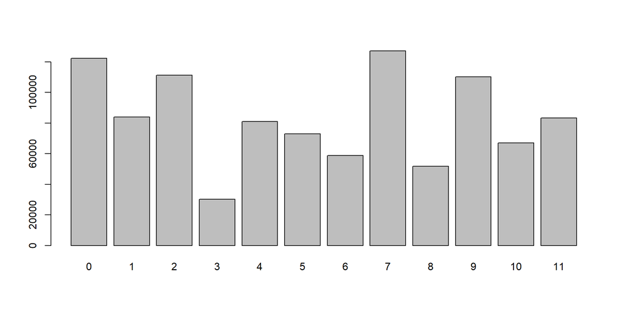

```r
plot(MSD$key)
```

Because the levels of `key` are not labelled, this plot is not interpretable.

## Data Processing

After importing data, the next step in the research process is *data processing*. This step involves labelling data, subsetting and splitting data into training and test samples.

This step can also involve *data cleaning*, which takes on various forms depending on the data. This may involve dealing outliers, missing data or other observations which the analyst deems to be problematic.

What we consider “problematic” depends on the research context, the available data, and the available tools to process the data. In the case of your BSAN2204 project, you should **NOT** consider “missing data” as problematic! (we will “deal with” missing data within the predictive analytics modelling)

## Writing data processing script

Up to this point, we have been working interactively in the console, running commands line by line to see immediate results for the purpose of exploring the data ourselves (but not for generating the report).

From here the code examples should be placed inside the `R` chunks of you `.Rmd` R Markdown file. We should also be diligent to name our R code block chunks, too (although it is OK if we forget to do this).

## Fencing

Fencing is the term used to describe the way we separate `R` code from narrative text. In R Markdown a “fence” starts and ends with three backticks (see below). In the first part of the fence, the language is specified (in our case `R`) and a name can also be optionally be given to help with document navigation.

**Exmaple**

**Fencing** off an `R` code chunk and naming it `labelling`:

````markdown
```{r labelling}

<labelling code placed here>

```
````

## Labelling factors

Labelling factors in `R` project is helpful because it makes your data clearer, more interpretable, and less error-prone. When factor levels are properly named, your analyses and visualisations become easier to understand, models run on correctly ordered categories, and collaborators can immediately see what each category represents.

Labelled factors turn raw categorical data into meaningful, readable information that supports cleaner workflows and more reliable results.

Knowing what to label your factors requires **contextual knowledge** of your data.

## Labelling factors in the `MSD`

The factor variables in the `MSD` are `key`, `mode` and `time signature`.

The `levels =` argument in `factor()` lets you specify the category names as a character vector, and factor() then uses these to encode the original vector as a categorical variable.

How should the levels of `key`, `mode` and `time signature` be appropriately labelled?

## Labelling `key`

A musical key defines the tonal centre of a piece. It is the pitch around which all other notes are organised. When combined with a mode (major or minor), it determines the scale that governs the harmonic and melodic structure of the music. In Western music, there are 12 distinct keys in the chromatic scale. Each key can be expressed in major or minor mode, giving a total of 24 key-mode combinations.

In the `MSD`, `key` is indexed numerically (0–11) using the chromatic scale:.

```r
MSD$key <- factor(MSD$key, levels = 0:11, labels = c(
  "C", "C#/Db", "D", "D#/Eb", "E", "F", "F#/Gb", "G", "G#/Ab", "A", "A#/Bb", "B"))
```

## Labelling `mode`

The mode of a song determines the overall “tonality” of music. Major keys known for their bright and happy sound. Minor keys evoke a more sombre and introspective mood.

Songs in a major key are more common in popular music than songs in a minor key. We can see from an inspection of the data that songs with `mode == 1` are about twice as common as songs with `mode == 0`, hence we can reliably assume here that `1` should be labelled “major” and `0` should be labelled “minor”.

```r
MSD$mode <- factor(MSD$mode, levels = c(0, 1), labels = c("minor", "major"))
```

## Labelling `time_signature`

Time signature tells you the rhythm of a song. Time signatures are written as two numbers stacked vertically (like a fraction). In the `MSD` the time signatures are estimated by using an algorithm to count the number of beats per 4 beat bar, and are categorised into 5 levels.

```r
MSD$time_signature <- factor(MSD$time_signature,
                      levels = c(1, 3, 4, 5, 7),
                      labels = c("1/4",
                                 "3/4 (Triple)",
                                 "4/4 (Common)",
                                 "5/4 (Quintuple)",
                                 "7/4 (Septuple)"))
```

[Click here to see a *literal wizard* demonstrate what different time signatures “sound like” on a drum”](https://www.youtube.com/watch?v=P45jlDNTf5Q)

## Data Subsetting

Subsetting is the process of selecting a portion of a dataset based on specified criteria. In practice, this means extracting certain rows, columns, or both from a larger data frame so that analysis can focus on the relevant observations or variables.

In the context of model building, subsetting refers to splitting the data into training and test data, so that the model can be fitted on one portion (the training data) and evaluated on another (the test data). This is known as model validation.

## Create your next `R` chunk

The next section of your Predictive Analytics Report will be called “subsetting” so use that as the name of your next `R` chunk. The structure of your `.Rmd` file should thus far be something link this:

````markdown
## Labelling

Plaintext describing how you are labelling the data goes here.

```{r labelling}

<labelling code placed here>

```

## Subsetting

Plaintext describing how you are subsetting the data goes here.

```{r subsetting}

<labelling code placed here>

```
````

## Subsetting the `MSD`

Working with all 1,000,000 observations *is possible* but knitting your Predictive Analytics Report to a `.html` will be slow if processing the entire dataset every time. To save your **sanity** whilst you build the initial report drafts, draw an *initial subset* that is significantly smaller than one million rows. Later, *if and only if you want to*, you can scale the analysis back up to a larger subset.

You may experiment with larger subsets, or with alternative methods (e.g., purposefully sampling based on the ranges of particular variables of interest).

Let’s start with an initial subset size of 12,500 randomly selected observations.

Working with the full `MSD` is not recommended. If you work with the full `MSD` (all 1 million observations) may result in your computer crashing later when dealing with missing data and/or model validation steps.

## Random sampling

To randomly sample 12,500 rows from the full `MSD` use:

```r
set.seed(123456)
MSD_subset <- MSD[sample(1:nrow(MSD), size = 12500), ]
```

This creates a new data frame object with the name `MSD_subset`. The row reference within the square brackets `[]` contains the `sample()` function. This function draws a 12,500 rows **at random** from all rows (1 to `nrow()`, i.e., 1 to 1,000,000, rows of the MSD).

`set.seed()` ensures the same random sample is drawn reproducibly each time the code is run.

## `set.seed()`

`set.seed()`is essential whenever your `R` code involves a random process. Setting a seed value ensures that any random process, such as when using `sample()`, will reproduce the same result every time the code is run.

This is particularly important in R Markdown: each time an `.Rmd` file is knitted, all code chunks are executed in a fresh session. Without `set.seed()`, functions like `sample()` would generate different random subsets every time you knit, leading to inconsistent results in your final `.html` output. Using `set.seed()` guarantees that the random steps in your analysis remain reproducible and stable.

We have used a seed value of `123456`, but any number can be used. Consider using your student ID number so your results are unique to you!

## Training Data vs Test Data

Later in the semester, we will learn about **model validation**, which is the process of checking how well a model performs on data it has not been trained on. To prepare for that step, we will split the subset of data we just created into two parts.

The first will be called `training_data`. This is the dataset we will use for all of our model training and initial analysis.

The second will be called `test_data`. This portion is set aside and not touched again until we reach the model validation stage. Using untouched data allows us to evaluate how well the model predicts new/unseen cases.

## Splitting the initial subset

The logic of splitting the intial subset involves first creating an index of rows of which rows from `MSD_subset` will be assigned to be used in as training data.

```r
training_index <- sample(1:nrow(MSD_subset), size = 0.80 * nrow(MSD_subset))

training_data <- MSD_subset[training_index, ]
test_data     <- MSD_subset[-training_index, ]
```

For `size =` instead of a fixed row number, we set it to `0.80 * nrow(MSD_subset)` (i.e., 80% of the number of rows in `MSD_subset`).

The training data is formed by selecting the rows listed in the index, whilst the test data is created by selecting the rows **not** listed in the index (using a negative index).

## Reporting the subset sizes

We can check the size of each of the two subsets by using `nrow()` and report a data frame object as nicely formatted table by piping it through to the tabulation package `kable()` in our R Markdown document.

```r
data.frame(
  Data = c("Full MSD", "Training Data", "Test Data"),
  Rows = c(nrow(MSD), nrow(training_data), nrow(test_data))
) |> kable()
```

| Data | Rows |
| --- | --- |
| Full MSD | 1000000 |
| Training Data | 10000 |
| Test Data | 2500 |

## Using `attach()`

Once you are satisfied the `training_data` data frame has been correctly set up, use the `attach()` function to make the variable names available as objects in your R session.

In the context of a R Markdown document, attaching the data frame makes the objects within in during the rendering process.

```r
attach(training_data)
```

Once you `attach(training_data)`, `R` will looks inside that data frame whenever you refer to a variable name, so you can use the variables directly without writing `training_data$variable_name`.

## Summary

We have covered a few things today:

- How to load the `MSD.Rdata` file using `load()`
- Explored the contents of the `MSD` using console commands
- Wrote data processing script for setting up factor labels (inside a labelled R chunk)
- Wrote data processing script to subset the data into training and test data (inside a *different* labelled R chunk)
- *Attached* the training data

Two key takeaways from today are: first, that the raw `R` console outputs generated was used only for our own exploration to check the data, whilst the actual data processing script was written in the source pane. Second, the test data has been set aside for now and will be used later when we evaluate model performance.

Thank you!